# vcl

Matt Biggs

## Connecting to UNC’s Virtual Computing Lab

The [VCL](https://vcl.unc.edu/) is a cluster of computers that is available to UNC students. It is similar to Amazon Web Services (AWS) and other “cloud” computing platforms. To use the VCL, you choose an “image”, which is a pre-defined operating system with software installed for you. You then reserve time on a server. Once your computer is ready, you connect to it using an SSH client.

### Reserve a new instance

Login to the VCL site, select “Reservations” from the left-hand menu and click “New Reservation”. This will bring up a new window where you can selet an image. The image “base_datasci611” has the software needed for BIOS 611.

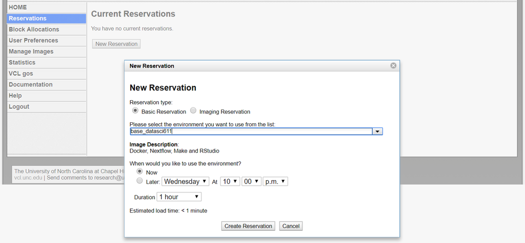

Select the environment you want, when and how long you want to reserve it for, then “Create Reservation”. The instance will take a few minutes to start up. Once the “Connect” button appears, click on it for the login credentials.

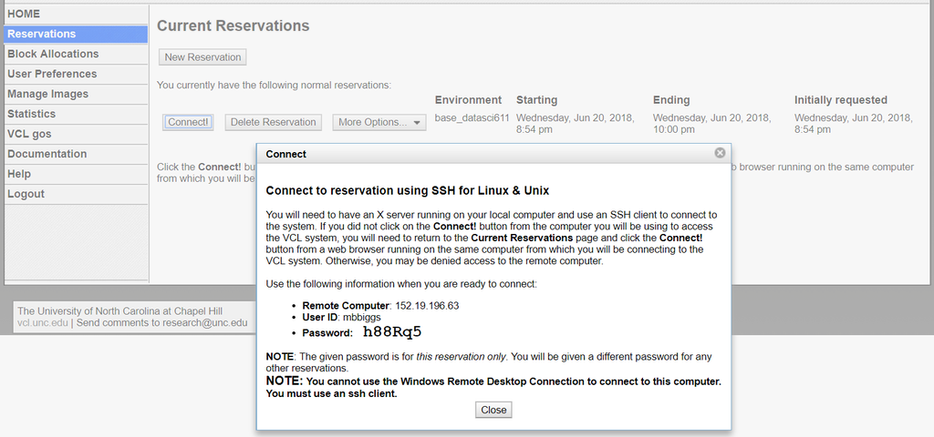

### Connecting from Linux/Mac

To connect from a Unix system, type a command something like the following (replacing with your own user ID and connection information):

```
ssh mbbiggs@152.19.196.63
```

Enter the password when prompted.

Once you are logged in, you can navigate around using standard Linux bash commands.

### Connecting from Windows 10

The most recent releases of Windows include several bash commands natively. You can call `ssh` and `scp` commands directly from the Windows command terminal just like on a Mac or Linux computer.

### Connecting from WinSCP

WinSCP is a tool for moving files to and from a remote server, and for running command line applications on that remote server. It will be a convenient tool for Windows users.

[WinSCP](https://winscp.net/eng/download.php) is a really good SSH client for Windows.

The first menu when you open WinSCP will prompt you for connection information. Choose “New Site” and input your user name, host address and password as provided by the VCL reservation.

[figure not shown]

Once connected, open a PuTTY session.

[figure not shown]

A successful PuTTY session will look just like a Unix terminal. You can navigate around using standard Linux bash commands.

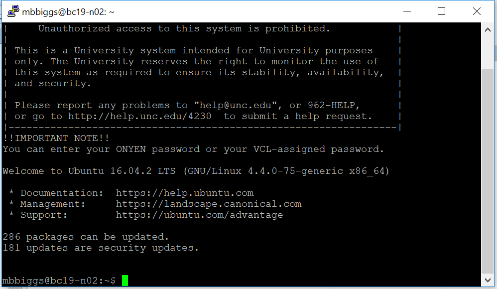

### Connecting from MobaXterm

[MobaXterm](https://mobaxterm.mobatek.net/) is an alternative to WinSCP. It is an SSH client that allows you to interact with remote unix servers via a command line terminal.

### FileZilla

Some students with Macs have reported using [FileZilla](https://filezilla-project.org/) as a client (like WinSCP).

### Cyberduck

Another possibility for accessing files remotely is [Cyberduck](https://cyberduck.io/).